# PracticalMachineLearning

rmydeen

4/25/2020

## Background

Using devices such as Jawbone Up, Nike FuelBand, and Fitbit it is now possible to collect a large amount of data about personal activity relatively inexpensively. These type of devices are part of the quantified self movement – a group of enthusiasts who take measurements about themselves regularly to improve their health, to find patterns in their behavior, or because they are tech geeks. One thing that people regularly do is quantify how much of a particular activity they do, but they rarely quantify how well they do it. In this project, your goal will be to use data from accelerometers on the belt, forearm, arm, and dumbell of 6 participants. They were asked to perform barbell lifts correctly and incorrectly in 5 different ways. More information is available from the website here: http://web.archive.org/web/20161224072740/http:/groupware.les.inf.puc-rio.br/har (see the section on the Weight Lifting Exercise Dataset).

## Data

The training data for this project are available here:

https://d396qusza40orc.cloudfront.net/predmachlearn/pml-training.csv

The test data are available here:

https://d396qusza40orc.cloudfront.net/predmachlearn/pml-testing.csv

The data for this project come from this source: http://web.archive.org/web/20161224072740/http:/groupware.les.inf.puc-rio.br/har. If you use the document you create for this class for any purpose please cite them as they have been very generous in allowing their data to be used for this kind of assignment

### 1.0 Library Loading

```r
library(caret)
```

```r
library(rpart)
library(rpart.plot)
library(randomForest)
library(corrplot)
```

### 2.0 Download data files

```r
trainingUrl <-"https://d396qusza40orc.cloudfront.net/predmachlearn/pml-training.csv"
testUrl <- "https://d396qusza40orc.cloudfront.net/predmachlearn/pml-testing.csv"
trainingFile <- "./learning-data/pml-training.csv"
testFile  <- "./learning-data/pml-testing.csv"
if (!file.exists("./learning-data")) {
  dir.create("./learning-data")
}
if (!file.exists(trainingFile)) {
  download.file(trainingUrl, destfile=trainingFile, method="curl")
}
if (!file.exists(testFile)) {
  download.file(testUrl, destfile=testFile, method="curl")
}
```

### 3.0 Read the Data

Read files into data frame

```r
training_data <- read.csv(trainingFile, na.strings = c("NA", "#DIV/0!", ""))
test_data <- read.csv(testFile, na.strings = c("NA", "#DIV/0!", ""))
dim(training_data)
```

```
## [1] 19622   160
```

```r
dim(test_data)
```

```
## [1]  20 160
```

### 4.0 Data cleaning

Let us remove those data contains more than 85% of the observation is NA and exclude those data.

```r
onlyCleanColumns <- colSums(is.na(training_data))/nrow(training_data) < 0.85
clean_data <- training_data[,onlyCleanColumns]
```

Make sure no NA records

```r
colSums(is.na(clean_data))/nrow(clean_data)
```

```
##                    X            user_name raw_timestamp_part_1
##                    0                    0                    0
## raw_timestamp_part_2       cvtd_timestamp           new_window
##                    0                    0                    0
##           num_window            roll_belt           pitch_belt
##                    0                    0                    0
##             yaw_belt     total_accel_belt         gyros_belt_x
##                    0                    0                    0
##         gyros_belt_y         gyros_belt_z         accel_belt_x
##                    0                    0                    0
##         accel_belt_y         accel_belt_z        magnet_belt_x
##                    0                    0                    0
##        magnet_belt_y        magnet_belt_z             roll_arm
##                    0                    0                    0
##            pitch_arm              yaw_arm      total_accel_arm
##                    0                    0                    0
##          gyros_arm_x          gyros_arm_y          gyros_arm_z
##                    0                    0                    0
##          accel_arm_x          accel_arm_y          accel_arm_z
##                    0                    0                    0
##         magnet_arm_x         magnet_arm_y         magnet_arm_z
##                    0                    0                    0
##        roll_dumbbell       pitch_dumbbell         yaw_dumbbell
##                    0                    0                    0
## total_accel_dumbbell     gyros_dumbbell_x     gyros_dumbbell_y
##                    0                    0                    0
##     gyros_dumbbell_z     accel_dumbbell_x     accel_dumbbell_y
##                    0                    0                    0
##     accel_dumbbell_z    magnet_dumbbell_x    magnet_dumbbell_y
##                    0                    0                    0
##    magnet_dumbbell_z         roll_forearm        pitch_forearm
##                    0                    0                    0
##          yaw_forearm  total_accel_forearm      gyros_forearm_x
##                    0                    0                    0
##      gyros_forearm_y      gyros_forearm_z      accel_forearm_x
##                    0                    0                    0
##      accel_forearm_y      accel_forearm_z     magnet_forearm_x
##                    0                    0                    0
##     magnet_forearm_y     magnet_forearm_z               classe
##                    0                    0                    0
```

```r
colSums(is.na(clean_data))
```

```
##                    X            user_name raw_timestamp_part_1
##                    0                    0                    0
## raw_timestamp_part_2       cvtd_timestamp           new_window
##                    0                    0                    0
##           num_window            roll_belt           pitch_belt
##                    0                    0                    0
##             yaw_belt     total_accel_belt         gyros_belt_x
##                    0                    0                    0
##         gyros_belt_y         gyros_belt_z         accel_belt_x
##                    0                    0                    0
##         accel_belt_y         accel_belt_z        magnet_belt_x
##                    0                    0                    0
##        magnet_belt_y        magnet_belt_z             roll_arm
##                    0                    0                    0
##            pitch_arm              yaw_arm      total_accel_arm
##                    0                    0                    0
##          gyros_arm_x          gyros_arm_y          gyros_arm_z
##                    0                    0                    0
##          accel_arm_x          accel_arm_y          accel_arm_z
##                    0                    0                    0
##         magnet_arm_x         magnet_arm_y         magnet_arm_z
##                    0                    0                    0
##        roll_dumbbell       pitch_dumbbell         yaw_dumbbell
##                    0                    0                    0
## total_accel_dumbbell     gyros_dumbbell_x     gyros_dumbbell_y
##                    0                    0                    0
##     gyros_dumbbell_z     accel_dumbbell_x     accel_dumbbell_y
##                    0                    0                    0
##     accel_dumbbell_z    magnet_dumbbell_x    magnet_dumbbell_y
##                    0                    0                    0
##    magnet_dumbbell_z         roll_forearm        pitch_forearm
##                    0                    0                    0
##          yaw_forearm  total_accel_forearm      gyros_forearm_x
##                    0                    0                    0
##      gyros_forearm_y      gyros_forearm_z      accel_forearm_x
##                    0                    0                    0
##      accel_forearm_y      accel_forearm_z     magnet_forearm_x
##                    0                    0                    0
##     magnet_forearm_y     magnet_forearm_z               classe
##                    0                    0                    0
```

Now let us remove the columns that do not contribute much to the accelerometer measurements

```r
classe <- clean_data$classe
trainRemove <- grepl("^X|timestamp|window", names(clean_data))
clean_data <- clean_data[, !trainRemove]
trainCleaned <- clean_data[, sapply(clean_data, is.numeric)]
trainCleaned$classe <- classe
testRemove <- grepl("^X|timestamp|window", names(test_data))
test_data <- test_data[, !testRemove]
testCleaned <- test_data[, sapply(test_data, is.numeric)]
```

Data set segregated into 75% of training set and 25% for testing set.

```r
inTrainIndex <- createDataPartition(trainCleaned$classe, p=0.75)[[1]]
training_training_data <- trainCleaned[inTrainIndex,]
training_crossval_data <- trainCleaned[-inTrainIndex,]
```

```r
allNames <- names(trainCleaned)
clean_test_data <- test_data[,allNames[1:52]]
```

### 5.0 Decision Tree Based - ML

The prediction accuracy is about 49% which is not at desired level with decision tree model.

```r
decisionTreeMod <- train(classe ~., method='rpart', data=training_training_data)

decisionTreePrediction <- predict(decisionTreeMod, training_crossval_data)
confusionMatrix(training_crossval_data$classe, decisionTreePrediction)
```

```
## Confusion Matrix and Statistics
##
##           Reference
## Prediction    A    B    C    D    E
##          A 1262   24  104    0    5
##          B  425  308  216    0    0
##          C  371   28  456    0    0
##          D  371  128  305    0    0
##          E  138  118  257    0  388
##
## Overall Statistics
##
##                Accuracy : 0.4923
##                  95% CI : (0.4782, 0.5063)
##     No Information Rate : 0.5235
##     P-Value [Acc > NIR] : 1
##
##                   Kappa : 0.3362
##
##  Mcnemar's Test P-Value : NA
##
## Statistics by Class:
##
##                      Class: A Class: B Class: C Class: D Class: E
## Sensitivity            0.4916  0.50825  0.34081       NA  0.98728
## Specificity            0.9431  0.85086  0.88811   0.8361  0.88628
## Pos Pred Value         0.9047  0.32455  0.53333       NA  0.43063
## Neg Pred Value         0.6281  0.92465  0.78217       NA  0.99875
## Prevalence             0.5235  0.12357  0.27284   0.0000  0.08014
## Detection Rate         0.2573  0.06281  0.09299   0.0000  0.07912
## Detection Prevalence   0.2845  0.19352  0.17435   0.1639  0.18373
## Balanced Accuracy      0.7174  0.67956  0.61446       NA  0.93678
```

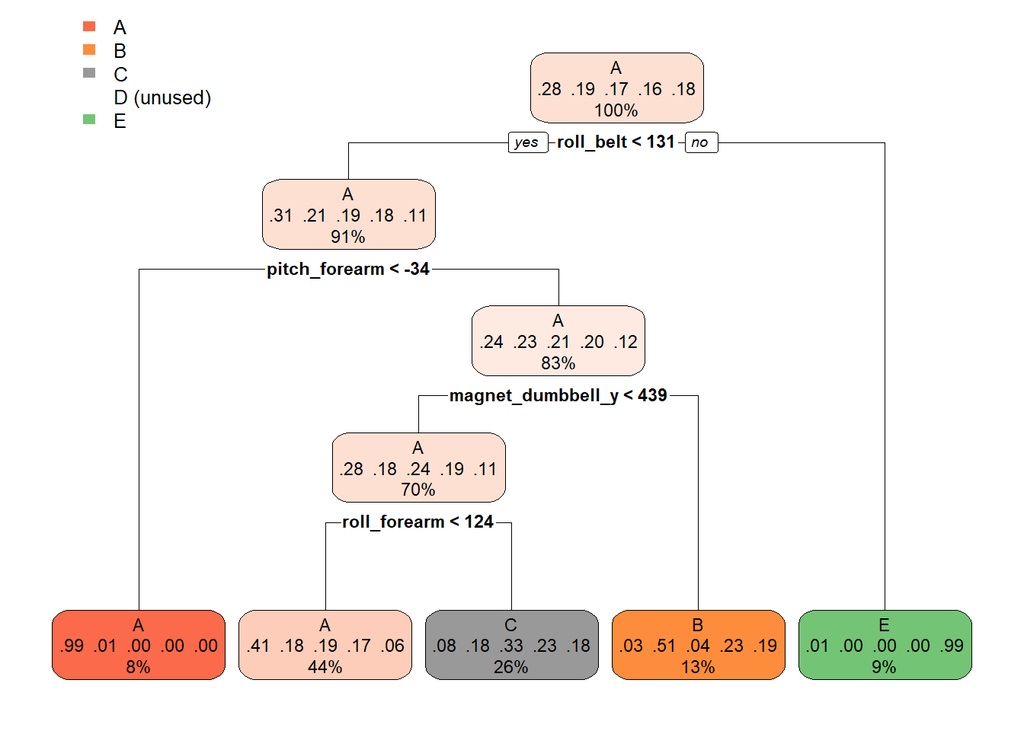

```r
rpart.plot(decisionTreeMod$finalModel)
```

### 6.0 Random Forest Based - ML

Using parallel core to ramp up running time for Random Forest.Write result into file and then reuse it .

```r
myRFModelFilename <- "myRFModel.RData"
if (!file.exists(myRFModelFilename)) {

    # Parallel cores required to run this program
    #require(parallel)
    library(doParallel)
    #Detect number of cores and take one less
    ncores <- makeCluster(detectCores() - 1)
    registerDoParallel(cores=ncores)
    getDoParWorkers()


    myRFModel <- train(classe ~ .
                , data = training_training_data
                , method = "rf"
                , metric = "Accuracy"
                , preProcess=c("center", "scale")
                , trControl=trainControl(method = "cv"
                                        , number = 4
                                        , p= 0.75
                                        , allowParallel = TRUE
                                        )
                )

    save(myRFModel, file = "myRFModel.RData")
    stopCluster(ncores)
} else {
    # Use cached model
    load(file = myRFModelFilename, verbose = TRUE)
}
```

```
## Loading objects:
##   myRFModel
```

```r
print(myRFModel, digits=4)
```

```
## Random Forest
##
## 14718 samples
##    52 predictor
##     5 classes: 'A', 'B', 'C', 'D', 'E'
##
## Pre-processing: centered (52), scaled (52)
## Resampling: Cross-Validated (4 fold)
## Summary of sample sizes: 11039, 11038, 11038, 11039
## Resampling results across tuning parameters:
##
##   mtry  Accuracy  Kappa
##    2    0.9910    0.9887
##   27    0.9900    0.9874
##   52    0.9797    0.9743
##
## Accuracy was used to select the optimal model using the largest value.
## The final value used for the model was mtry = 2.
```

```r
rfPrediction <- predict(myRFModel, training_crossval_data)
rf_conf<-confusionMatrix(training_crossval_data$classe, rfPrediction)
rf_conf
```

```
## Confusion Matrix and Statistics
##
##           Reference
## Prediction    A    B    C    D    E
##          A 1395    0    0    0    0
##          B    0  949    0    0    0
##          C    0    2  853    0    0
##          D    0    0    3  801    0
##          E    0    0    0    3  898
##
## Overall Statistics
##
##                Accuracy : 0.9984
##                  95% CI : (0.9968, 0.9993)
##     No Information Rate : 0.2845
##     P-Value [Acc > NIR] : < 2.2e-16
##
##                   Kappa : 0.9979
##
##  Mcnemar's Test P-Value : NA
##
## Statistics by Class:
##
##                      Class: A Class: B Class: C Class: D Class: E
## Sensitivity            1.0000   0.9979   0.9965   0.9963   1.0000
## Specificity            1.0000   1.0000   0.9995   0.9993   0.9993
## Pos Pred Value         1.0000   1.0000   0.9977   0.9963   0.9967
## Neg Pred Value         1.0000   0.9995   0.9993   0.9993   1.0000
## Prevalence             0.2845   0.1939   0.1746   0.1639   0.1831
## Detection Rate         0.2845   0.1935   0.1739   0.1633   0.1831
## Detection Prevalence   0.2845   0.1935   0.1743   0.1639   0.1837
## Balanced Accuracy      1.0000   0.9989   0.9980   0.9978   0.9996
```

Prediction

```r
predict(myRFModel, clean_test_data)
```

```
##  [1] B A B A A E D B A A B C B A E E A B B B
## Levels: A B C D E
```

Plot the prediction From the Confusion Matrix fro RF, we can see that the prediction accuracy of Random Forest model is about 99% in satisfactory level.

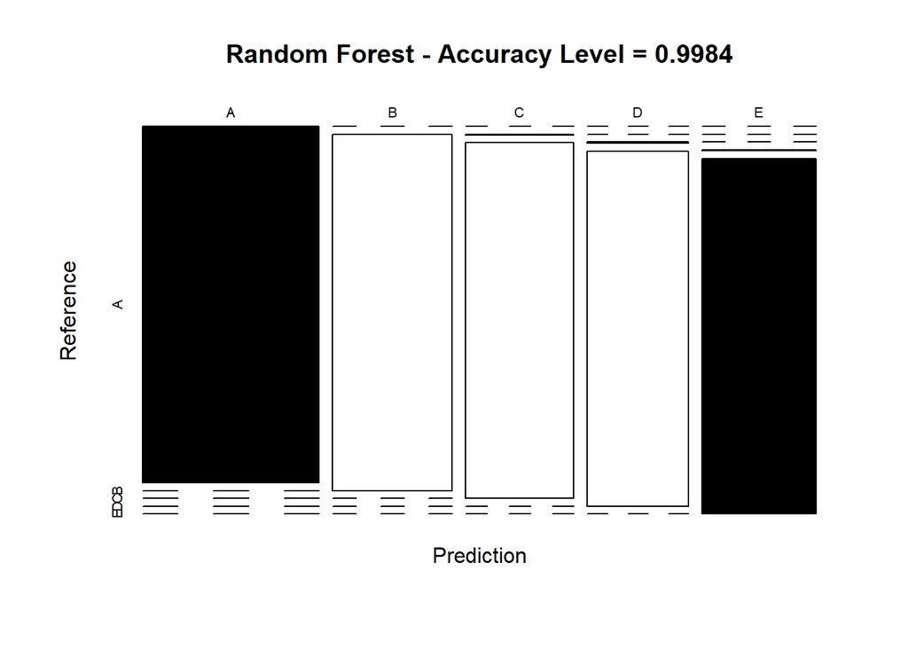

```r
plot(rf_conf$table, col = rf_conf$byClass,
     main = paste("Random Forest - Accuracy Level =",
                  round(rf_conf$overall['Accuracy'], 4)))
```